# Biostat 212a Homework 4

Due Mar. 4, 2025 @ 11:59PM

Author

Molly Shi (UID: 906558988)

Published

March 4, 2025

```r
library(ISLR2)
library(tidymodels)
library(tidyverse)
library(ranger)
library(GGally)
library(gtsummary)
library(xgboost)
library(dplyr)
library(rpart.plot)
library(vip)
library(ggplot2)
library(patchwork)
library(ape)
library(ggtree)
```

## 1 ISL Exercise 8.4.3 (10pts)

Consider the Gini index, classification error, and cross-entropy in a simple classification setting with two classes. Create a single plot that displays each of these quantities as a function of $\hat{p}_{m1}$. The $x$-axis should display $\hat{p}_{m1}$, ranging from 0 to 1, and the $y$-axis should display the value of the Gini index, classification error, and entropy.

Hint: In a setting with two classes, $\hat{p}_{m1} = 1 - \hat{p}_{m2}$. You could make this plot by hand, but it will be much easier to make in R.

**Solution**

The Gini *index* is defined by

$$G = \sum_{k=1}^{K} \hat{p}_{mk}(1 - \hat{p}_{mk})$$

Cross entropy is given by

$$D = -\sum_{k=1}^{K} \hat{p}_{mk}\log(\hat{p}_{mk})$$

The classification error is

$$E = 1 - \max_k(\hat{p}_{mk})$$

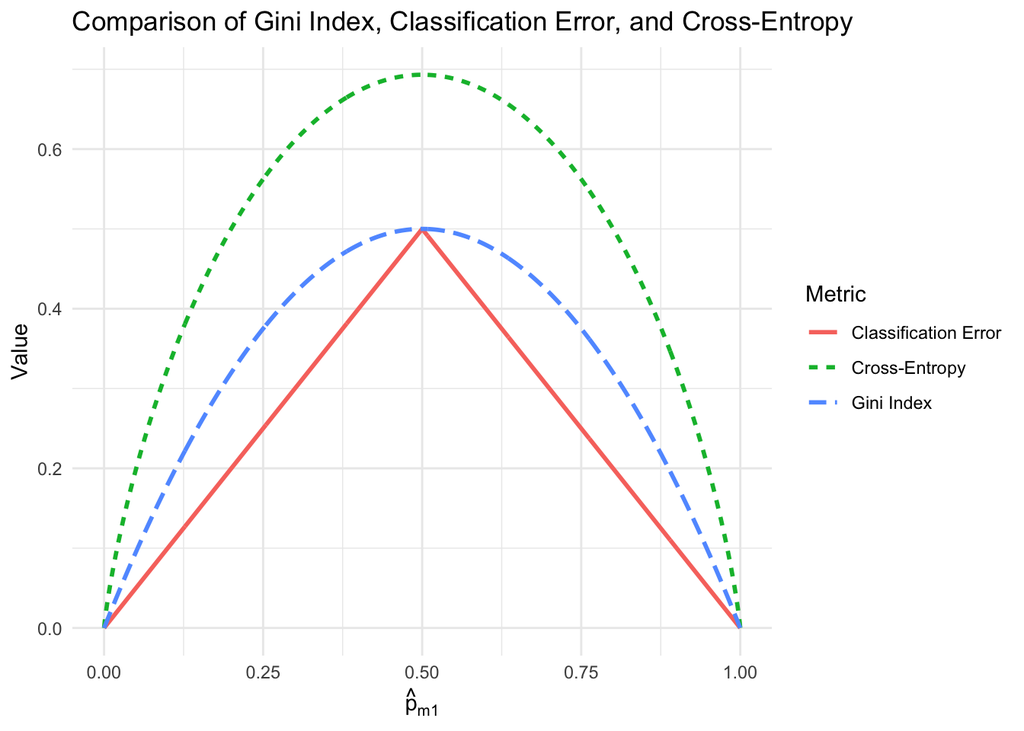

```r
p_hat_m1 <- seq(0, 1, length.out = 1000)

gini_index <- 2 * p_hat_m1 * (1 - p_hat_m1)

classification_error <- 1 - pmax(p_hat_m1, 1 - p_hat_m1)

epsilon <- 1e-10
cross_entropy <- - (p_hat_m1 * log(p_hat_m1 + epsilon) + (1 - p_hat_m1) * log(1 - p_hat_m1 + epsilon))

df <- data.frame(
  p_hat_m1 = rep(p_hat_m1, 3),
  Value = c(gini_index, classification_error, cross_entropy),
  Metric = rep(c("Gini Index", "Classification Error", "Cross-Entropy"), each = length(p_hat_m1))
)

# Plotting
ggplot(df, aes(x = p_hat_m1, y = Value, color = Metric, linetype = Metric)) +
  geom_line(size = 1) +
  labs(title = "Comparison of Gini Index, Classification Error, and Cross-Entropy",
       x = expression(hat(p)[m1]),
       y = "Value") +
  theme_minimal()
```

## 2 ISL Exercise 8.4.4 (10pts)

This question relates to the plots in Figure 8.14.

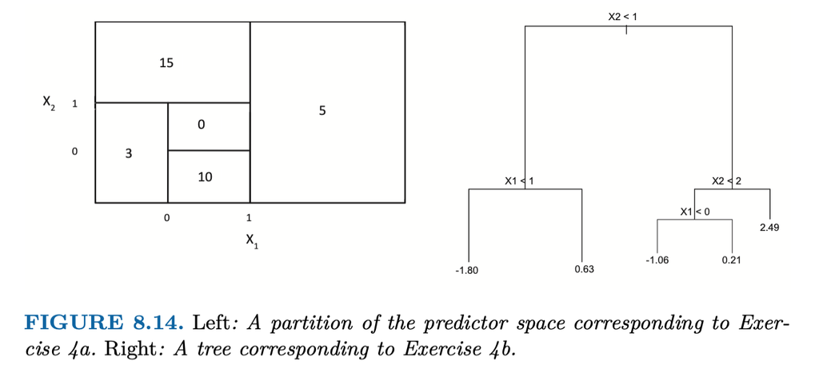

1. Sketch the tree corresponding to the partition of the predictor space illustrated in the left-hand panel of Figure 8.14. The numbers inside the boxes indicate the mean of $Y$ within each region.

   **Solution**

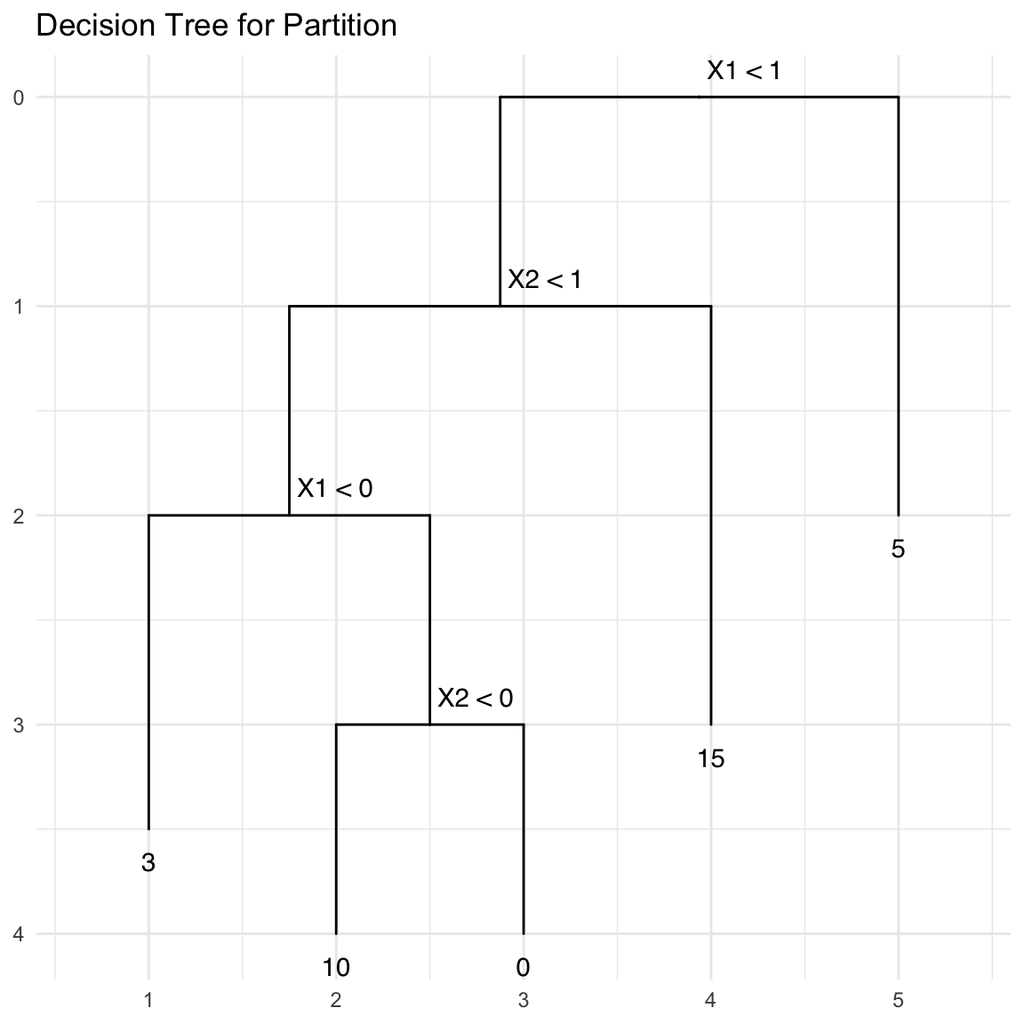

   ```r
   tree <- read.tree(text = "(((3:1.5,(10:1,0:1)A:1)B:1,15:2)C:1,5:2)D;")
   tree$node.label <- c("X1 < 1", "X2 < 1", "X1 < 0", "X2 < 0")

   # Plot tree with improved aesthetics
   ggtree(tree, ladderize = FALSE) +
     scale_x_reverse() + coord_flip() +
     geom_tiplab(vjust = 2, hjust = 0.5) +
     geom_text2(aes(label = label, subset = !isTip), hjust = -0.1, vjust = -1) +
     ggtitle("Decision Tree for Partition") +
     theme_minimal()
   ```

2. Create a diagram similar to the left-hand panel of Figure 8.14, using the tree illustrated in the right-hand panel of the same figure. You should divide up the predictor space into the correct regions, and indicate the mean for each region.

   **Solution**

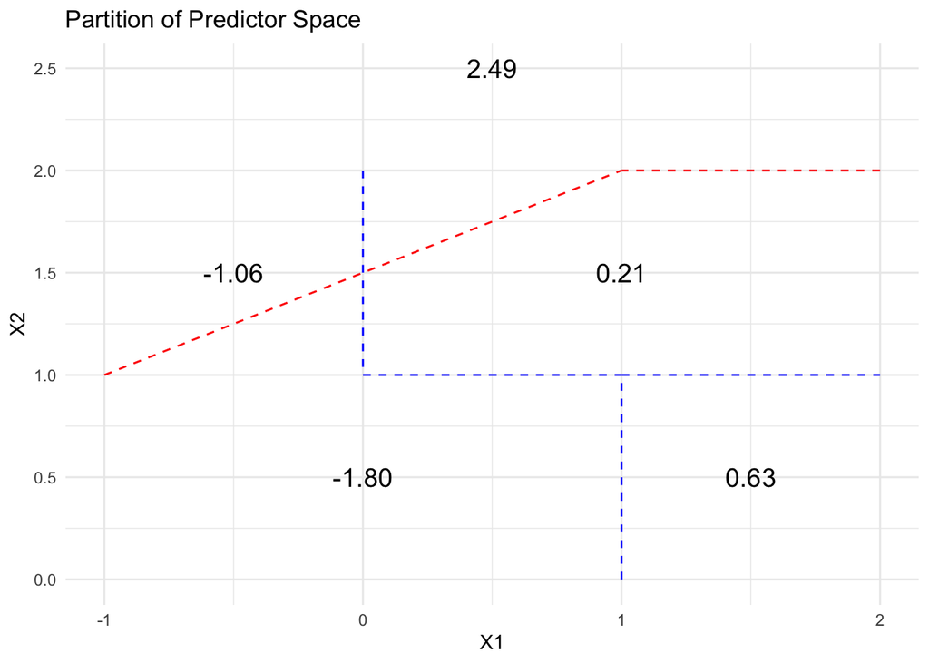

   ```r
   partition_lines <- data.frame(
     x = c(NA, -1, 2, 0, 0, 1, 1), # NA for non-connected lines
     xend = c(NA, 1, 1, 0, 1, 1, 2),
     y = c(1, 1, 2, 2, 1, 0, 1),
     yend = c(1, 2, 2, 1, 1, 1, 1),
     color = c("red", "red", "red", "blue", "blue", "blue", "blue")
   )

   # Define text labels for regions
   region_labels <- data.frame(
     x = c(0, 1.5, -0.5, 1, 0.5),
     y = c(0.5, 0.5, 1.5, 1.5, 2.5),
     label = c("-1.80", "0.63", "-1.06", "0.21", "2.49")
   )

   # Create the partition plot
   ggplot() +
     geom_segment(data = partition_lines, aes(x = x, xend = xend, y = y, yend = yend, color = color), linetype = "dashed") +
     geom_text(data = region_labels, aes(x = x, y = y, label = label), size = 5) +
     scale_color_manual(values = c("red" = "red", "blue" = "blue")) +
     labs(x = "X1", y = "X2", title = "Partition of Predictor Space") +
     theme_minimal() +
     theme(legend.position = "none")
   ```

## 3 ISL Exercise 8.4.5 (10pts)

Suppose we produce ten bootstrapped samples from a data set containing red and green classes. We then apply a classification tree to each bootstrapped sample and, for a specific value of $X$, produce 10 estimates of $P(\textrm{Class is Red}|X)$:
$$0.1, 0.15, 0.2, 0.2, 0.55, 0.6, 0.6, 0.65, 0.7, \textrm{and } 0.75.$$
There are two common ways to combine these results together into a single class prediction. One is the majority vote approach discussed in this chapter. The second approach is to classify based on the average probability. In this example, what is the final classification under each of these two approaches?

**Solution**

For majority vote approach, Each tree predicts a probability $P(\textrm{Class is Red}|X)$, and we classify based on whether this probability is greater than 0.5. If $P(\textrm{Class is Red}|X) > 0.5$, the prediction will be red and vice versa. Using the majority vote approach, the final classification result will be red.

```r
x <- c(0.1, 0.15, 0.2, 0.2, 0.55, 0.6, 0.6, 0.65, 0.7, 0.75)

# Majority vote approach
majority_vote <- ifelse(sum(x > 0.5) > length(x) / 2, "Red", "Green")
cat("Majority Vote Classification:", majority_vote)
```

```
Majority Vote Classification: Red
```

The average probability approach uses the average of the estimated probabilities to predict the class. Using the average probability approach, the final classification result will be green.

```r
# Average probability approach
average_prob <- ifelse(mean(x) > 0.5, "Red", "Green")
cat("Average Probability Classification:", average_prob)
```

```
Average Probability Classification: Green
```

## 4 ISL Lab 8.3. `Boston` data set (30pts)

Follow the machine learning workflow to train regression tree, random forest, and boosting methods for predicting `medv`. Evaluate out-of-sample performance on a test set.

**Solution**

```r
# ================================
# Train Test Split
# ================================
set.seed(42)

data_split <- initial_split(Boston, prop = 0.8)
train_set <- training(data_split)
test_set <- testing(data_split)

# Print training and test set dimensions
cat("Training set dimension:",dim(train_set), "\n")
```

```
Training set dimension: 404 13
```

```r
cat("Test set dimension:", dim(test_set))
```

```
Test set dimension: 102 13
```

```r
# ================================
# Preprocessing
# ================================
data_recipe <- recipe(medv ~ ., data = train_set) %>%
  step_naomit(medv) %>%
  step_zv(all_numeric_predictors())

data_recipe
```

```r
# ================================
# Regression Tree Model
# ================================
regtree_mod <- decision_tree(
  cost_complexity = tune(),
  tree_depth = tune(),
  min_n = 5,
  mode = "regression",
  engine = "rpart"
)

tree_wf <- workflow() %>%
  add_recipe(data_recipe) %>%
  add_model(regtree_mod)

tree_param_grid <- grid_regular(cost_complexity(),
                          tree_depth(),
                          levels = c(100, 5))

# ================================
# Random Forest Model
# ================================
rf_mod <- rand_forest(
    mode = "regression",
    mtry = tune(),
    trees = tune()
  ) %>%
  set_engine("ranger", importance = "impurity")

rf_wf <- workflow() %>%
  add_recipe(data_recipe) %>%
  add_model(rf_mod)

rf_param_grid <- grid_regular(
  trees(range = c(100L, 300L)),
  mtry(range = c(1L, 5L)),
  levels = c(3, 5)
)

# ================================
# Boosting Model (XGBoost)
# ================================
boost_mod <- boost_tree(
    mode = "regression",
    trees = 1000,
    tree_depth = tune(),
    learn_rate = tune()
  ) %>%
  set_engine("xgboost")

boost_wf <- workflow() %>%
  add_recipe(data_recipe) %>%
  add_model(boost_mod)

boost_param_grid <- grid_regular(
  tree_depth(range = c(1L, 4L)),
  learn_rate(range = c(-3, -0.5), trans = log10_trans()),
  levels = c(3, 5)
  )
```

```r
# ================================
# Cross-validation for All Models
# ================================
set.seed(42)
folds <- vfold_cv(train_set, v = 5)

# Tune and evaluate all models
tune_and_select <- function(wf, param_grid) {
  wf %>%
    tune_grid(
      resamples = folds,
      grid = param_grid,
      metrics = metric_set(rmse, rsq)
    ) %>%
    select_best(metric = "rmse")
}

best_tree <- tune_and_select(tree_wf, tree_param_grid)
best_rf <- tune_and_select(rf_wf, rf_param_grid)
best_boost <- tune_and_select(boost_wf, boost_param_grid)
```

```r
# ================================
# Finalize and Evaluate Models
# ================================
final_fit_and_evaluate <- function(wf, best_params, label) {
  final_wf <- wf %>% finalize_workflow(best_params)
  final_fit <- final_wf %>% last_fit(data_split)
  cat("\n", label, "Test Metrics:\n")
  print(final_fit %>% collect_metrics())
  return(final_fit)
}

final_fit_tree <- final_fit_and_evaluate(tree_wf, best_tree, "Regression Tree")
```

```
 Regression Tree Test Metrics:
# A tibble: 2 × 4
  .metric .estimator .estimate .config
  <chr>   <chr>          <dbl> <chr>
1 rmse    standard       3.48  Preprocessor1_Model1
2 rsq     standard       0.889 Preprocessor1_Model1
```

```r
final_fit_rf <- final_fit_and_evaluate(rf_wf, best_rf, "Random Forest")
```

```
 Random Forest Test Metrics:
# A tibble: 2 × 4
  .metric .estimator .estimate .config
  <chr>   <chr>          <dbl> <chr>
1 rmse    standard       3.65  Preprocessor1_Model1
2 rsq     standard       0.896 Preprocessor1_Model1
```

```r
final_fit_boost <- final_fit_and_evaluate(boost_wf, best_boost, "Boosting")
```

```
 Boosting Test Metrics:
# A tibble: 2 × 4
  .metric .estimator .estimate .config
  <chr>   <chr>          <dbl> <chr>
1 rmse    standard       2.70  Preprocessor1_Model1
2 rsq     standard       0.934 Preprocessor1_Model1
```

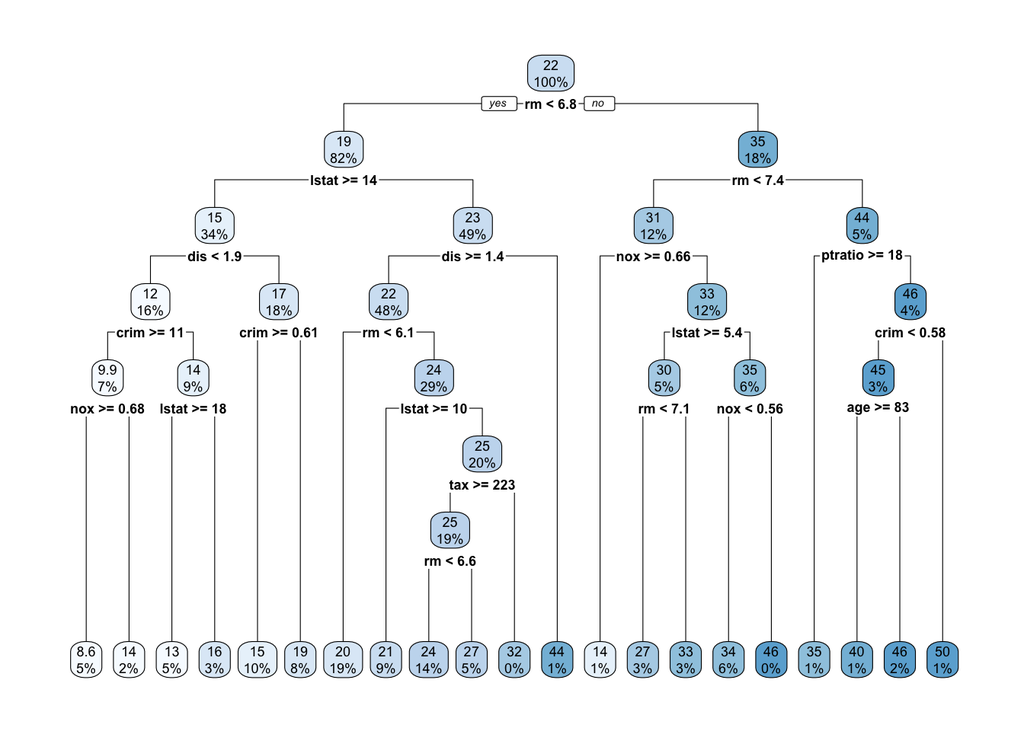

```r
# ================================
# Visualize Regression Tree Models
# ================================
final_tree <- extract_workflow(final_fit_tree) %>%
  extract_fit_engine() %>%
  rpart.plot(roundint = FALSE)
```

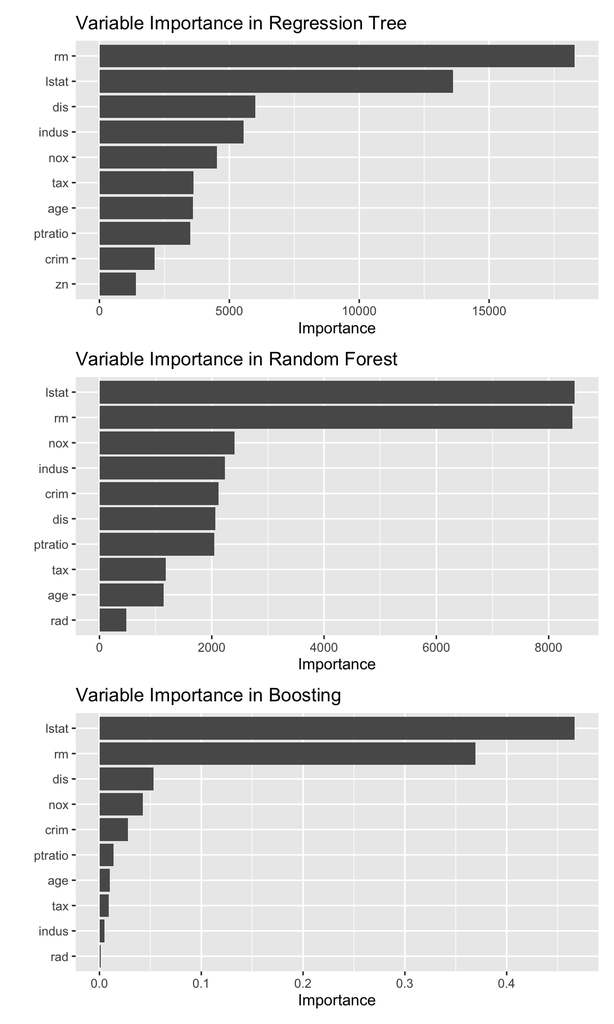

```r
# ================================
# Visualize Variable Importance
# ================================
plot_variable_importance <- function(final_fit, model_name) {
  final_model <- final_fit %>%
    extract_workflow() %>%  # Extract the workflow
    extract_fit_parsnip()   # Extract the model
  vip(final_model) +
    labs(title = paste("Variable Importance in", model_name))
}

tree_var_importance <- plot_variable_importance(final_fit_tree, "Regression Tree")
rf_var_importance <- plot_variable_importance(final_fit_rf, "Random Forest")
boosting_var_importance <- plot_variable_importance(final_fit_boost, "Boosting")

# Combine plots using patchwork
(tree_var_importance) / (rf_var_importance) / (boosting_var_importance)
```

```r
# ================================
# Compare Model Performance
# ================================
# Function to extract model metrics
extract_final_metrics <- function(final_fit, model_name) {
  metrics <- final_fit %>%
    collect_metrics() %>%
    select(.metric, .estimate) %>%
    pivot_wider(names_from = .metric, values_from = .estimate) %>%
    mutate(Model = model_name)

  return(metrics)
}

# Collect metrics for each model
metrics_tree <- extract_final_metrics(final_fit_tree, "Regression Tree")
metrics_rf <- extract_final_metrics(final_fit_rf, "Random Forest")
metrics_boost <- extract_final_metrics(final_fit_boost, "Boosting")

# Combine results into a single dataframe
final_results <- bind_rows(metrics_tree, metrics_rf, metrics_boost)

# Print the final results
print(final_results)
```

```
# A tibble: 3 × 3
   rmse   rsq Model
  <dbl> <dbl> <chr>
1  3.48 0.889 Regression Tree
2  3.65 0.896 Random Forest
3  2.70 0.934 Boosting
```

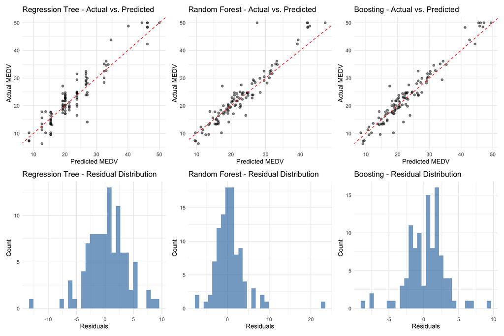

```r
# ================================
# Visualizing Model Performance
# ================================
# Function to create actual vs predicted plot
plot_actual_vs_predicted <- function(final_fit, model_name) {
  results <- collect_predictions(final_fit) # Extract predictions

  ggplot(results, aes(x = .pred, y = medv)) +
    geom_point(alpha = 0.5) +
    geom_abline(slope = 1, intercept = 0, color = "red", linetype = "dashed") +
    labs(title = paste(model_name, "- Actual vs. Predicted"),
         x = "Predicted MEDV", y = "Actual MEDV") +
    theme_minimal()
}

# Function to plot residuals
plot_residuals <- function(final_fit, model_name) {
  results <- collect_predictions(final_fit) %>%
    mutate(residual = medv - .pred) # Compute residuals

  ggplot(results, aes(x = residual)) +
    geom_histogram(fill = "steelblue", bins = 30, alpha = 0.7) +
    labs(title = paste(model_name, "- Residual Distribution"),
         x = "Residuals", y = "Count") +
    theme_minimal()
}

# Generate plots for each model
plot_tree_pred <- plot_actual_vs_predicted(final_fit_tree, "Regression Tree")
plot_rf_pred <- plot_actual_vs_predicted(final_fit_rf, "Random Forest")
plot_boost_pred <- plot_actual_vs_predicted(final_fit_boost, "Boosting")

plot_tree_resid <- plot_residuals(final_fit_tree, "Regression Tree")
plot_rf_resid <- plot_residuals(final_fit_rf, "Random Forest")
plot_boost_resid <- plot_residuals(final_fit_boost, "Boosting")

# Combine plots using patchwork
(plot_tree_pred | plot_rf_pred | plot_boost_pred) /
(plot_tree_resid | plot_rf_resid | plot_boost_resid)
```

## 5 ISL Lab 8.3 `Carseats` data set (30pts)

Follow the machine learning workflow to train classification tree, random forest, and boosting methods for classifying `Sales <= 8` versus `Sales > 8`. Evaluate out-of-sample performance on a test set.

**Solution**

```r
# ================================
# Train Test Split
# ================================
set.seed(42)

data_split <- initial_split(Carseats, prop = 0.8)
train_set <- training(data_split)
test_set <- testing(data_split)

# Print training and test set dimensions
cat("Training set dimension:",dim(train_set), "\n")
```

```
Training set dimension: 320 11
```

```r
cat("Test set dimension:", dim(test_set))
```

```
Test set dimension: 80 11
```

```r
# ================================
# Preprocessing
# ================================
data_recipe <- recipe(Sales ~ ., data = train_set) %>%
  # Convert Sales to binary class
  step_mutate(Sales = factor(ifelse(Sales > 8, "High", "Low"))) %>%
  step_naomit(all_predictors()) %>%
  step_dummy(all_nominal_predictors()) %>%
  step_zv(all_numeric_predictors()) %>%
  step_normalize(all_numeric_predictors())

data_recipe
```

```r
# ================================
# Classification Tree Model
# ================================
tree_mod <- decision_tree(
  cost_complexity = tune(),
  tree_depth = tune(),
  min_n = 5,
  mode = "classification",
  engine = "rpart"
)

tree_wf <- workflow() %>%
  add_recipe(data_recipe) %>%
  add_model(tree_mod)

tree_param_grid <- grid_regular(cost_complexity(),
                          tree_depth(),
                          levels = c(100, 5))

# ================================
# Random Forest Model
# ================================
rf_mod <- rand_forest(
    mode = "classification",
    mtry = tune(),
    trees = tune()
  ) %>%
  set_engine("ranger", importance = "impurity")

rf_wf <- workflow() %>%
  add_recipe(data_recipe) %>%
  add_model(rf_mod)

rf_param_grid <- grid_regular(
  trees(range = c(100L, 300L)),
  mtry(range = c(1L, 5L)),
  levels = c(3, 5)
)

# ================================
# Boosting Model (XGBoost)
# ================================
boost_mod <- boost_tree(
    mode = "classification",
    trees = 1000,
    tree_depth = tune(),
    learn_rate = tune()
  ) %>%
  set_engine("xgboost")

boost_wf <- workflow() %>%
  add_recipe(data_recipe) %>%
  add_model(boost_mod)

boost_param_grid <- grid_regular(
  tree_depth(range = c(1L, 3L)),
  learn_rate(range = c(-5, -2), trans = log10_trans()),
  levels = c(3, 10)
  )
```

```r
# ================================
# Cross-validation for All Models
# ================================
set.seed(42)
folds <- vfold_cv(train_set, v = 5)

# Tune and select best models
tune_and_select <- function(wf, param_grid) {
  wf %>%
    tune_grid(
      resamples = folds,
      grid = param_grid,
      metrics = metric_set(accuracy, roc_auc)  # Use classification metrics
    ) %>%
    select_best(metric = "accuracy")  # Optimize for accuracy
}

best_tree <- tune_and_select(tree_wf, tree_param_grid)
best_rf <- tune_and_select(rf_wf, rf_param_grid)
best_boost <- tune_and_select(boost_wf, boost_param_grid)
```

```r
# ================================
# Finalize and Evaluate Models
# ================================
final_fit_and_evaluate <- function(wf, best_params, label) {
  final_wf <- wf %>% finalize_workflow(best_params)
  final_fit <- final_wf %>% last_fit(data_split)
  cat("\n", label, "Test Metrics:\n")
  print(final_fit %>% collect_metrics())  # Classification metrics
  return(final_fit)
}

final_fit_tree <- final_fit_and_evaluate(tree_wf, best_tree, "Classification Tree")
```

```
 Classification Tree Test Metrics:
# A tibble: 3 × 4
  .metric     .estimator .estimate .config
  <chr>       <chr>          <dbl> <chr>
1 accuracy    binary         0.688 Preprocessor1_Model1
2 roc_auc     binary         0.738 Preprocessor1_Model1
3 brier_class binary         0.238 Preprocessor1_Model1
```

```r
final_fit_rf <- final_fit_and_evaluate(rf_wf, best_rf, "Random Forest")
```

```
 Random Forest Test Metrics:
# A tibble: 3 × 4
  .metric     .estimator .estimate .config
  <chr>       <chr>          <dbl> <chr>
1 accuracy    binary         0.838 Preprocessor1_Model1
2 roc_auc     binary         0.917 Preprocessor1_Model1
3 brier_class binary         0.134 Preprocessor1_Model1
```

```r
final_fit_boost <- final_fit_and_evaluate(boost_wf, best_boost, "Boosting")
```

```
 Boosting Test Metrics:
# A tibble: 3 × 4
  .metric     .estimator .estimate .config
  <chr>       <chr>          <dbl> <chr>
1 accuracy    binary         0.825 Preprocessor1_Model1
2 roc_auc     binary         0.920 Preprocessor1_Model1
3 brier_class binary         0.116 Preprocessor1_Model1
```

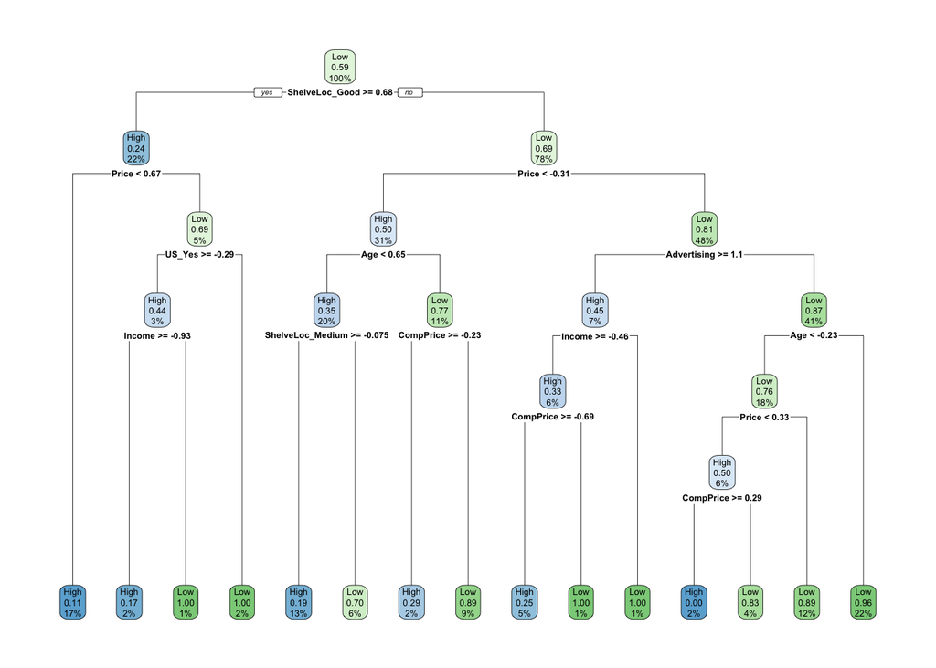

```r
# ================================
# Visualize Regression Tree Models
# ================================
final_tree <- extract_workflow(final_fit_tree) %>%
  extract_fit_engine() %>%
  rpart.plot(roundint = FALSE)
```

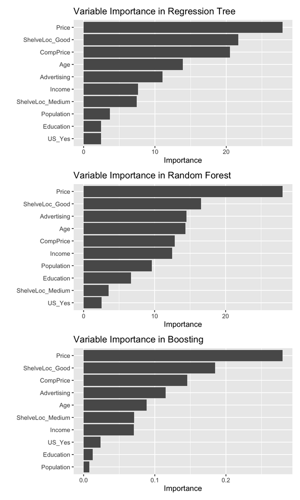

```r
# ================================
# Visualize Variable Importance
# ================================
plot_variable_importance <- function(final_fit, model_name) {
  final_model <- final_fit %>%
    extract_workflow() %>%  # Extract the workflow
    extract_fit_parsnip()   # Extract the model
  vip(final_model) +
    labs(title = paste("Variable Importance in", model_name))
}

tree_var_importance <- plot_variable_importance(final_fit_tree, "Regression Tree")
rf_var_importance <- plot_variable_importance(final_fit_rf, "Random Forest")
boosting_var_importance <- plot_variable_importance(final_fit_boost, "Boosting")

# Combine plots using patchwork
(tree_var_importance) / (rf_var_importance) / (boosting_var_importance)
```

```r
# ================================
# Compare Model Performance
# ================================
# Function to extract model metrics
extract_final_metrics <- function(final_fit, model_name) {
  metrics <- final_fit %>%
    collect_metrics() %>%
    select(.metric, .estimate) %>%
    pivot_wider(names_from = .metric, values_from = .estimate) %>%
    mutate(Model = model_name)

  return(metrics)
}

# Collect metrics for each model
metrics_tree <- extract_final_metrics(final_fit_tree, "Regression Tree")
metrics_rf <- extract_final_metrics(final_fit_rf, "Random Forest")
metrics_boost <- extract_final_metrics(final_fit_boost, "Boosting")

# Combine results into a single dataframe
final_results <- bind_rows(metrics_tree, metrics_rf, metrics_boost)

# Print the final results
print(final_results)
```

```
# A tibble: 3 × 4
  accuracy roc_auc brier_class Model
     <dbl>   <dbl>       <dbl> <chr>
1    0.688   0.738       0.238 Regression Tree
2    0.838   0.917       0.134 Random Forest
3    0.825   0.920       0.116 Boosting
```

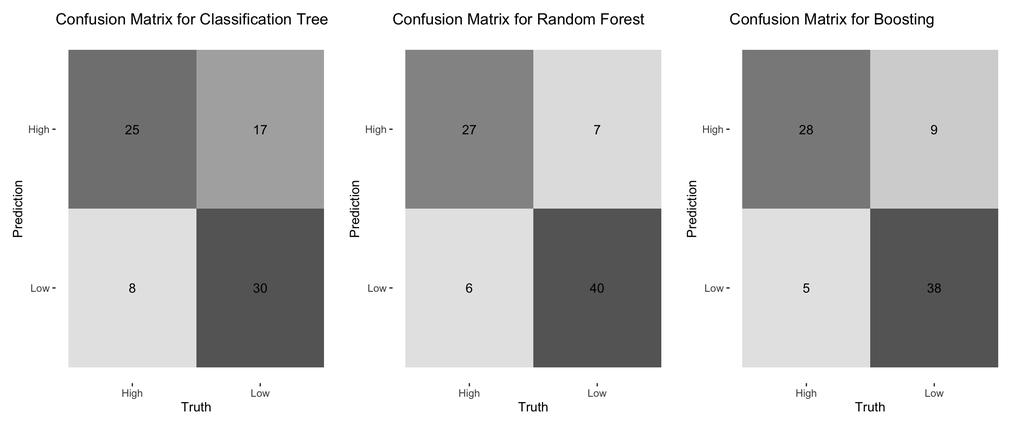

```r
# ================================
# Visualizing Model Performance
# ================================
plot_conf_matrix <- function(final_fit, model_name) {
  predictions <- collect_predictions(final_fit)

  conf_mat <- conf_mat(predictions, truth = Sales, estimate = .pred_class) %>%
    autoplot(type = "heatmap") +
    labs(title = paste("Confusion Matrix for", model_name))

  return(conf_mat)
}

tree_cm <- plot_conf_matrix(final_fit_tree, "Classification Tree")
rf_cm <- plot_conf_matrix(final_fit_rf, "Random Forest")
boost_cm <- plot_conf_matrix(final_fit_boost, "Boosting")

# Combine plots using patchwork
(tree_cm | rf_cm | boost_cm)
```